# DAB300 - LAB 3 - Building an Image Classifier from Scratch

The main goal of this lab is to create an image classifier from scratch using the Keras package. You will create a binary classifier based on an object type of your choice. The classifier will accept images and then predict whether or not a given image contains that object. For example, if you chose your object to be a cat, then the classifier would accept images and predict 1 if it believes there is a cat in the image or a 0 if not.

## GROUP NUMBER: 17

- Meghaben - W0749147
- Vipin - W0755900
- Yasmin - W0754285
- Urmi - W0756341
- Trang Bui - W0753523

## Part 1: Prep Work - Choose an Object & Create a Dataset

#### Create a Dataset

- Chosen Object : mapple leave
- 80 pictures of mapple leaves with various of forms, colors
- 80 pictures of other objects excluding mapple leaves
- Training set includes 50 picture of mapple leaves, and 50 pictures of other objects. These are directories of train set

  ```
    + ../mapledataset/train/maple/
    + ../mapledataset/train/nomaple/
  ```

- Test set includes 15 picture of mapple leaves, and 15 pictures of other objects. These are directories of validation set

  ```
    + ../mapledataset/val/maple/
    + ../mapledataset/val/nomaple/
  ```

## Part 2: Using the Original Data

```python
import collections
import numpy as np
import matplotlib.pyplot as plt
import PIL
import time

import warnings
warnings.filterwarnings('ignore')
import time
import os, sys
from datetime import datetime, date

import tensorflow as tf
from tensorflow import keras
from tensorflow.keras.preprocessing.image import ImageDataGenerator
from tensorflow.keras.models import Sequential
from tensorflow.keras.layers import Conv2D, Flatten, Dense, Dropout, Activation
from tensorflow.keras.layers import MaxPooling2D
from tensorflow.keras.utils import to_categorical
from tensorflow.keras.callbacks import EarlyStopping

from tensorflow.keras.layers import BatchNormalization


train_dir ='mapledataset/train/'
test_dir='mapledataset/test/'
val_dir='mapledataset/val/'


print('VERIFY THE NUMBER OF IMAGE IN FOLDER')
path_train = os.listdir(train_dir)
maple_train = os.listdir(train_dir+ path_train[0])
nomaple_train = os.listdir(train_dir+ path_train[1])
print("Number of maple images in train in maple:", len(maple_train))
print("Number of nomapple images in train in nomaple: ", len(nomaple_train))


path_test = os.listdir(test_dir)
maple_test = os.listdir(test_dir+ path_test[0])
nomaple_test = os.listdir(test_dir+ path_test[1])
print("Number of maple images in test: ", len(maple_test))
print("Number of nomapple images in test: ", len(nomaple_test))

path_val = os.listdir(val_dir)
maple_val = os.listdir(val_dir+ path_val[0])
nomaple_val = os.listdir(val_dir+ path_val[1])
print("Number of maple images in validation: ", len(maple_val))
print("Number of nomapple images in validation: ", len(nomaple_val))
```

```
VERIFY THE NUMBER OF IMAGE IN FOLDER
Number of maple images in train in maple: 50
Number of nomapple images in train in nomaple:  50
Number of maple images in test:  15
Number of nomapple images in test:  15
Number of maple images in validation:  15
Number of nomapple images in validation:  15
```

```
==================================================================================================================
Part 2-1: Dataset Loading and Processing with Image Data Generators
Define target image shape: (148, 148, 3)
Define batch size that is the number of images to extract from folder for each of batch: 10
Define directories of Train, Test, and Validate Sets.
Train Dir:  ../ mapledataset/train/
Test Dir:  ../ mapledataset/test/
Validation Dir:  ../ mapledataset/val/
Create a data generator with the input parameter "rescale" to determine that the image pixel values are rescaled between 0 and 1.
-----Load and iterate TRAIN, TEST, VALIDATION using "flow_from_directory"
Found 100 images belonging to 2 classes.
Found 30 images belonging to 2 classes.
Found 30 images belonging to 2 classes.
==================================================================================================================
Part 2-2: Dataset Verification
Batch shape: X= (10, 148, 148, 3)
Range of rescale: min= 0.0 , max= 1.0
*PLOT 9 FIRST IMAGES
```

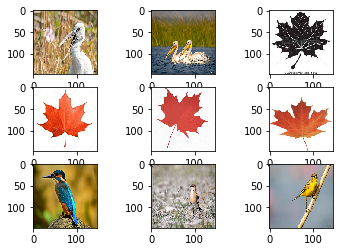

```
==================================================================================================================
Part 2-3: Create and Evaluate a Model
Model: "sequential"
_________________________________________________________________
Layer (type)                 Output Shape              Param #
=================================================================
conv2d (Conv2D)              (None, 146, 146, 64)      1792
_________________________________________________________________
activation (Activation)      (None, 146, 146, 64)      0
_________________________________________________________________
max_pooling2d (MaxPooling2D) (None, 73, 73, 64)        0
_________________________________________________________________
conv2d_1 (Conv2D)            (None, 71, 71, 64)        36928
_________________________________________________________________
activation_1 (Activation)    (None, 71, 71, 64)        0
_________________________________________________________________
max_pooling2d_1 (MaxPooling2 (None, 35, 35, 64)        0
_________________________________________________________________
conv2d_2 (Conv2D)            (None, 33, 33, 32)        18464
_________________________________________________________________
activation_2 (Activation)    (None, 33, 33, 32)        0
_________________________________________________________________
max_pooling2d_2 (MaxPooling2 (None, 16, 16, 32)        0
_________________________________________________________________
conv2d_3 (Conv2D)            (None, 14, 14, 32)        9248
_________________________________________________________________
activation_3 (Activation)    (None, 14, 14, 32)        0
_________________________________________________________________
max_pooling2d_3 (MaxPooling2 (None, 7, 7, 32)          0
_________________________________________________________________
flatten (Flatten)            (None, 1568)              0
_________________________________________________________________
dense (Dense)                (None, 16)                25104
_________________________________________________________________
activation_4 (Activation)    (None, 16)                0
_________________________________________________________________
dense_1 (Dense)              (None, 1)                 17
_________________________________________________________________
activation_5 (Activation)    (None, 1)                 0
=================================================================
```

[output cut: 29 more lines]

```
10/10 - 3s - loss: 0.1422 - accuracy: 0.9600 - val_loss: 1.2044 - val_accuracy: 0.5667
10/10 - 2s - loss: 0.1882 - accuracy: 0.9300 - val_loss: 0.1922 - val_accuracy: 0.9667
10/10 - 2s - loss: 0.0735 - accuracy: 0.9800 - val_loss: 0.4192 - val_accuracy: 0.9000
10/10 - 2s - loss: 0.0946 - accuracy: 0.9700 - val_loss: 0.3532 - val_accuracy: 0.8667
10/10 - 2s - loss: 0.0786 - accuracy: 0.9800 - val_loss: 0.1527 - val_accuracy: 0.9667
10/10 - 2s - loss: 0.0213 - accuracy: 0.9900 - val_loss: 0.2132 - val_accuracy: 0.9667
10/10 - 2s - loss: 0.0984 - accuracy: 0.9600 - val_loss: 0.3113 - val_accuracy: 0.9333
10/10 - 2s - loss: 0.0151 - accuracy: 0.9900 - val_loss: 0.1321 - val_accuracy: 0.9333
10/10 - 2s - loss: 0.0060 - accuracy: 1.0000 - val_loss: 0.1607 - val_accuracy: 0.9333
10/10 - 2s - loss: 0.0013 - accuracy: 1.0000 - val_loss: 0.2139 - val_accuracy: 0.9667
10/10 - 2s - loss: 7.0248e-04 - accuracy: 1.0000 - val_loss: 0.2547 - val_accuracy: 0.9667
10/10 - 2s - loss: 0.1017 - accuracy: 0.9800 - val_loss: 0.2258 - val_accuracy: 0.9000
10/10 - 2s - loss: 0.0030 - accuracy: 1.0000 - val_loss: 0.1893 - val_accuracy: 0.9333
Total Training Time (second): 47.470553398132324
Visualize the progress our network makes on the loss and accuracy as the number of epochs increases.
```

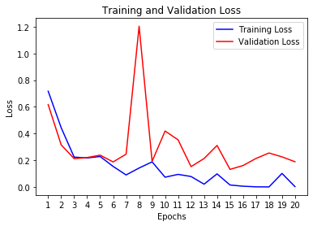

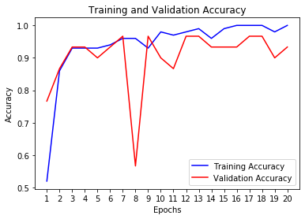

```
Prediction using test set.
WARNING:tensorflow:sample_weight modes were coerced from
  ...
    to
  ['...']
3/3 - 0s - loss: 0.6117 - accuracy: 0.8333
0.8333333
```

```python
print('==================================================================================================================')
print('Part 2-1: Dataset Loading and Processing with Image Data Generators')
v_width=148
v_height=148
v_depth=3  # color image
input_shape = (v_width, v_height, v_depth)
print('Define target image shape:', input_shape)

v_batch_size=10
print('Define batch size that is the number of images to extract from folder for each of batch:', v_batch_size)


print('Define directories of Train, Test, and Validate Sets.')
print('Train Dir:  ../', train_dir)
print('Test Dir:  ../', test_dir)
print('Validation Dir:  ../', val_dir)


print('Create a data generator with the input parameter "rescale" to determine that the image pixel values are rescaled between 0 and 1.')
datagen = ImageDataGenerator(rescale=1./255)

print('-----Load and iterate TRAIN, TEST, VALIDATION using "flow_from_directory"')
train_gen = datagen.flow_from_directory(train_dir, target_size=(v_width, v_height), class_mode='binary', batch_size=v_batch_size)
test_gen = datagen.flow_from_directory(test_dir, target_size=(v_width, v_height), class_mode='binary', batch_size=v_batch_size)
val_gen = datagen.flow_from_directory(val_dir, target_size=(v_width, v_height), class_mode='binary', batch_size=v_batch_size)


print('==================================================================================================================')
print('Part 2-2: Dataset Verification')
train_data, train_labels = train_gen.next()
print('Batch shape: X=', (train_data.shape))
print('Range of rescale: min=', train_data.min(),', max=', train_data.max())

val_data, val_labels = val_gen.next()
test_data, test_labels = test_gen.next()

print('*PLOT 9 FIRST IMAGES')
for i in range(9):
    plt.subplot(330 + 1 + i)
    plt.imshow(train_data[i]) # plot raw pixel data
plt.show()



print('==================================================================================================================')
print('Part 2-3: Create and Evaluate a Model')

def fn_BuildModel(p_optimizer,p_loss,p_metrics):
    model = Sequential()
    model.add(Conv2D(64, (3, 3), input_shape=input_shape))
    model.add(Activation('relu'))
    model.add(MaxPooling2D(pool_size=(2, 2)))

    model.add(Conv2D(64, (3, 3)))
    model.add(Activation('relu'))
    model.add(MaxPooling2D(pool_size=(2, 2)))

    model.add(Conv2D(32, (3, 3)))
    model.add(Activation('relu'))
    model.add(MaxPooling2D(pool_size=(2, 2)))

    model.add(Conv2D(32, (3, 3)))
    model.add(Activation('relu'))
    model.add(MaxPooling2D(pool_size=(2, 2)))

    model.add(Flatten())
    model.add(Dense(16))
    model.add(Activation('relu'))

    model.add(Dense(1))
    model.add(Activation('sigmoid'))

    model.compile(optimizer=p_optimizer,
                loss=p_loss,
                metrics=[p_metrics])

    return model


def fn_Train(modelname, model, p_train_gen, p_epochs, p_batch_size, p_val_gen, p_test_gen):
    print('Modelname:',modelname)
    print('Optimizer:', p_optimizer)
    print('Loss',p_loss)
    print('Metrics',p_metrics)

    early_stop = EarlyStopping(monitor = 'val_accuracy', patience = 3)

    start_time = time.time()

    print('Model Compile with optimizer, loss function and evaluation method')

    print('Model Training to see the tensor shapes and number of parameters for each layer')
    # The values for the training loss and accuracy, as well as the validation loss and accuracy, are stored in the history variable
    history = model.fit_generator(p_train_gen,
                    epochs = p_epochs,
                    validation_data=p_val_gen,
                    validation_steps = p_batch_size,verbose=2)

    print('Total Training Time (second):', time.time() - start_time)

    print('Visualize the progress our network makes on the loss and accuracy as the number of epochs increases.')

    history.history.keys()
    history_dict = history.history # the dictionary that has the information on loss and accuracy per epoch

    loss_values = history_dict['loss']   # training loss
    val_loss_values = history_dict['val_loss'] # validation loss

    epochs = range(1, len(loss_values)+1)  #creates list of integers to match the number of epochs of training

    # code to plot the results
    plt.plot(epochs, loss_values, 'b', label="Training Loss")
    plt.plot(epochs, val_loss_values, 'r', label="Validation Loss")
    plt.title("Training and Validation Loss")
    plt.xlabel("Epochs")
    plt.xticks(epochs)
    plt.ylabel("Loss")
    plt.legend()
    plt.show()

    # As above, but this time we want to visualize the training and validation accuracy
    acc_values = history_dict['accuracy']
    val_acc_values = history_dict['val_accuracy']

    plt.plot(epochs, acc_values, 'b', label="Training Accuracy")
    plt.plot(epochs, val_acc_values, 'r', label="Validation Accuracy")
    plt.title("Training and Validation Accuracy")
    plt.xlabel("Epochs")
    plt.xticks(epochs)
    plt.ylabel("Accuracy")
    plt.legend()
    plt.show()


    print('Prediction using test set.')
    test_loss, test_acc = model.evaluate(p_test_gen, verbose=2)
    print(test_acc)
    return


p_loss = 'binary_crossentropy'
p_metrics = 'accuracy'
p_epochs=20
p_batch_size=3
p_optimizer= 'rmsprop' #rmsprop
model = fn_BuildModel(p_optimizer,p_loss,p_metrics)
model.summary()
fn_Train('Sequential Model',model,train_gen, p_epochs, p_batch_size, val_gen, test_gen)
```

## Part 3: Using Data Augmentation

#### Dataset Verification

You should verify that the training, validation, and test sets have the correct number of images (the `os` functions should help with this) and that the data is organized in a folder structure that will work with your image data generators.

#### Dataset Loading and Processing with Create Image Data Generators

You should now create image data generators for your training, validation, and test datasets that will allow you to feed them into your model in batches. The images should be resized to 148x148 pixels and scaled so all pixel values are between 0 and 1.

#### Add Data Augmentation

You should now add data augmentation to your training data generator. All available types of augmentation should be used.

Print an image and examples of the same image augmented in different ways. (The `.load_img()` and `.flow()` methods may be helpful here.)

#### Create and Evaluate a Baseline Model

Use the best model from **Part 2** to train with the augmented data and evaluate on the validation data to get a baseline accuracy for the new model trained on the augmented dataset.

#### Tune the Model

With a more complex training set, you may be able to improve the accuracy through adjustments to the baseline model architecture and tuning the hyperparameters.

#### Report Accuracy on Test Set

Your final step is to make predictions using the test set and report the final test set accuracy. It may be helpful to use `batch_size=1` for this step.

```
Apply rotation of augmentation method
-----Load and iterate TRAIN, TEST, VALIDATION using "flow_from_directory"
Found 100 images belonging to 2 classes.
==================================================================================================================
 Dataset Verification
Batch shape: X= (10, 148, 148, 3)
Range of rescale: min= 0.0 , max= 1.0
*PLOT 9 FIRST IMAGES
```

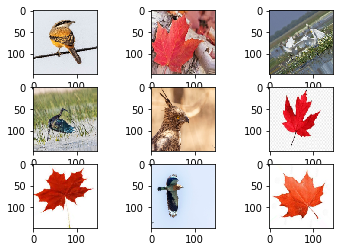

```
Dataset Verification after adding Data Augmentation
Batch shape: X= (10, 148, 148, 3)
Range of rescale: min= 0.0 , max= 1.0
Model: "sequential_1"
_________________________________________________________________
Layer (type)                 Output Shape              Param #
=================================================================
conv2d_4 (Conv2D)            (None, 146, 146, 64)      1792
_________________________________________________________________
activation_6 (Activation)    (None, 146, 146, 64)      0
_________________________________________________________________
max_pooling2d_4 (MaxPooling2 (None, 73, 73, 64)        0
_________________________________________________________________
conv2d_5 (Conv2D)            (None, 71, 71, 64)        36928
_________________________________________________________________
activation_7 (Activation)    (None, 71, 71, 64)        0
_________________________________________________________________
max_pooling2d_5 (MaxPooling2 (None, 35, 35, 64)        0
_________________________________________________________________
conv2d_6 (Conv2D)            (None, 33, 33, 32)        18464
_________________________________________________________________
activation_8 (Activation)    (None, 33, 33, 32)        0
_________________________________________________________________
max_pooling2d_6 (MaxPooling2 (None, 16, 16, 32)        0
_________________________________________________________________
conv2d_7 (Conv2D)            (None, 14, 14, 32)        9248
_________________________________________________________________
activation_9 (Activation)    (None, 14, 14, 32)        0
_________________________________________________________________
max_pooling2d_7 (MaxPooling2 (None, 7, 7, 32)          0
_________________________________________________________________
flatten_1 (Flatten)          (None, 1568)              0
_________________________________________________________________
dense_2 (Dense)              (None, 16)                25104
_________________________________________________________________
activation_10 (Activation)   (None, 16)                0
_________________________________________________________________
dense_3 (Dense)              (None, 1)                 17
_________________________________________________________________
activation_11 (Activation)   (None, 1)                 0
```

[output cut: 27 more lines]

```
10/10 - 3s - loss: 0.2590 - accuracy: 0.9400 - val_loss: 0.3277 - val_accuracy: 0.8667
10/10 - 3s - loss: 0.1440 - accuracy: 0.9700 - val_loss: 0.1601 - val_accuracy: 0.9333
10/10 - 3s - loss: 0.0896 - accuracy: 0.9600 - val_loss: 0.2582 - val_accuracy: 0.9333
10/10 - 3s - loss: 0.1465 - accuracy: 0.9400 - val_loss: 0.1488 - val_accuracy: 0.9333
10/10 - 3s - loss: 0.1017 - accuracy: 0.9600 - val_loss: 0.1522 - val_accuracy: 0.9667
10/10 - 3s - loss: 0.1132 - accuracy: 0.9600 - val_loss: 0.2377 - val_accuracy: 0.9000
10/10 - 3s - loss: 0.0830 - accuracy: 0.9700 - val_loss: 0.1719 - val_accuracy: 0.9333
10/10 - 3s - loss: 0.0779 - accuracy: 0.9800 - val_loss: 0.1824 - val_accuracy: 0.9667
10/10 - 3s - loss: 0.1181 - accuracy: 0.9500 - val_loss: 0.1593 - val_accuracy: 0.9667
10/10 - 3s - loss: 0.1331 - accuracy: 0.9500 - val_loss: 0.2445 - val_accuracy: 0.9000
10/10 - 3s - loss: 0.0570 - accuracy: 0.9900 - val_loss: 0.2665 - val_accuracy: 0.9333
10/10 - 3s - loss: 0.0758 - accuracy: 0.9500 - val_loss: 0.1535 - val_accuracy: 0.9333
10/10 - 3s - loss: 0.0441 - accuracy: 0.9900 - val_loss: 0.2100 - val_accuracy: 0.9333
Total Training Time (second): 56.024895906448364
Visualize the progress our network makes on the loss and accuracy as the number of epochs increases.
```

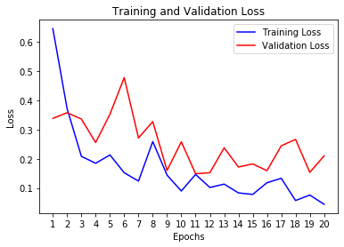

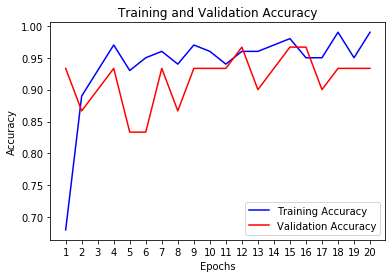

```
Prediction using test set.
WARNING:tensorflow:sample_weight modes were coerced from
  ...
    to
  ['...']
3/3 - 0s - loss: 0.7130 - accuracy: 0.7667
0.76666665
```

```python
print('Apply rotation of augmentation method')

datagen_aug1 = ImageDataGenerator(rescale = 1/255., rotation_range=40)


print('-----Load and iterate TRAIN, TEST, VALIDATION using "flow_from_directory"')
train_gen = datagen_aug1.flow_from_directory(train_dir, target_size=(v_width, v_height), class_mode='binary', batch_size=v_batch_size)

print('==================================================================================================================')
print(' Dataset Verification')
train_data, train_labels = train_gen.next()
print('Batch shape: X=', (train_data.shape))
print('Range of rescale: min=', train_data.min(),', max=', train_data.max())

val_data, val_labels = val_gen.next()
test_data, test_labels = test_gen.next()

print('*PLOT 9 FIRST IMAGES')
for i in range(9):
    plt.subplot(330 + 1 + i)
    plt.imshow(train_data[i]) # plot raw pixel data
plt.show()

print('Dataset Verification after adding Data Augmentation ')
train_data, train_labels = train_gen.next()
print('Batch shape: X=', (train_data.shape))
print('Range of rescale: min=', train_data.min(),', max=', train_data.max())


p_loss = 'binary_crossentropy'
p_metrics = 'accuracy'
p_epochs=20
p_batch_size=3
p_optimizer= 'rmsprop' #rmsprop
model = fn_BuildModel(p_optimizer,p_loss,p_metrics)
model.summary()
fn_Train('Sequential Model',model,train_gen, p_epochs, p_batch_size, val_gen, test_gen)
```

```
Apply Flipping of augmentation method
-----Load and iterate TRAIN, TEST, VALIDATION using "flow_from_directory"
Found 100 images belonging to 2 classes.
==================================================================================================================
 Dataset Verification
Batch shape: X= (10, 148, 148, 3)
Range of rescale: min= 0.0 , max= 1.0
*PLOT 9 FIRST IMAGES
```

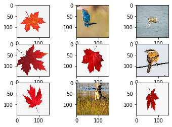

```
Dataset Verification after adding Data Augmentation
Batch shape: X= (10, 148, 148, 3)
Range of rescale: min= 0.0 , max= 1.0
Model: "sequential_2"
_________________________________________________________________
Layer (type)                 Output Shape              Param #
=================================================================
conv2d_8 (Conv2D)            (None, 146, 146, 64)      1792
_________________________________________________________________
activation_12 (Activation)   (None, 146, 146, 64)      0
_________________________________________________________________
max_pooling2d_8 (MaxPooling2 (None, 73, 73, 64)        0
_________________________________________________________________
conv2d_9 (Conv2D)            (None, 71, 71, 64)        36928
_________________________________________________________________
activation_13 (Activation)   (None, 71, 71, 64)        0
_________________________________________________________________
max_pooling2d_9 (MaxPooling2 (None, 35, 35, 64)        0
_________________________________________________________________
conv2d_10 (Conv2D)           (None, 33, 33, 32)        18464
_________________________________________________________________
activation_14 (Activation)   (None, 33, 33, 32)        0
_________________________________________________________________
max_pooling2d_10 (MaxPooling (None, 16, 16, 32)        0
_________________________________________________________________
conv2d_11 (Conv2D)           (None, 14, 14, 32)        9248
_________________________________________________________________
activation_15 (Activation)   (None, 14, 14, 32)        0
_________________________________________________________________
max_pooling2d_11 (MaxPooling (None, 7, 7, 32)          0
_________________________________________________________________
flatten_2 (Flatten)          (None, 1568)              0
_________________________________________________________________
dense_4 (Dense)              (None, 16)                25104
_________________________________________________________________
activation_16 (Activation)   (None, 16)                0
_________________________________________________________________
dense_5 (Dense)              (None, 1)                 17
_________________________________________________________________
activation_17 (Activation)   (None, 1)                 0
```

[output cut: 27 more lines]

```
10/10 - 3s - loss: 0.1847 - accuracy: 0.9200 - val_loss: 0.1697 - val_accuracy: 0.9667
10/10 - 3s - loss: 0.0884 - accuracy: 0.9800 - val_loss: 0.1705 - val_accuracy: 0.9667
10/10 - 3s - loss: 0.1774 - accuracy: 0.9500 - val_loss: 0.2390 - val_accuracy: 0.9333
10/10 - 3s - loss: 0.0988 - accuracy: 0.9600 - val_loss: 0.1787 - val_accuracy: 0.9667
10/10 - 3s - loss: 0.1387 - accuracy: 0.9500 - val_loss: 0.1729 - val_accuracy: 0.9667
10/10 - 3s - loss: 0.0931 - accuracy: 0.9800 - val_loss: 0.1928 - val_accuracy: 0.9667
10/10 - 3s - loss: 0.0741 - accuracy: 0.9700 - val_loss: 0.2912 - val_accuracy: 0.9667
10/10 - 3s - loss: 0.1237 - accuracy: 0.9400 - val_loss: 0.1913 - val_accuracy: 0.8667
10/10 - 3s - loss: 0.1049 - accuracy: 0.9600 - val_loss: 0.1608 - val_accuracy: 0.9333
10/10 - 3s - loss: 0.0443 - accuracy: 0.9900 - val_loss: 0.2131 - val_accuracy: 0.9667
10/10 - 3s - loss: 0.1098 - accuracy: 0.9500 - val_loss: 0.1435 - val_accuracy: 0.9667
10/10 - 3s - loss: 0.0558 - accuracy: 0.9700 - val_loss: 0.2088 - val_accuracy: 0.9667
10/10 - 3s - loss: 0.1002 - accuracy: 0.9600 - val_loss: 0.2179 - val_accuracy: 0.9667
Total Training Time (second): 56.84500551223755
Visualize the progress our network makes on the loss and accuracy as the number of epochs increases.
```

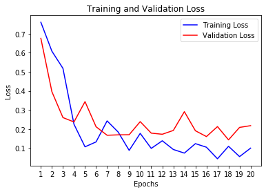

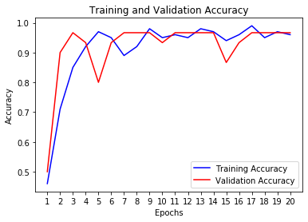

```
Prediction using test set.
WARNING:tensorflow:sample_weight modes were coerced from
  ...
    to
  ['...']
3/3 - 0s - loss: 0.7403 - accuracy: 0.7667
0.76666665
```

```python
print('Apply Flipping of augmentation method')

datagen_aug2 = ImageDataGenerator(rescale = 1/255.,
      horizontal_flip=True,
      vertical_flip=True)


print('-----Load and iterate TRAIN, TEST, VALIDATION using "flow_from_directory"')
train_gen = datagen_aug2.flow_from_directory(train_dir, target_size=(v_width, v_height), class_mode='binary', batch_size=v_batch_size)

print('==================================================================================================================')
print(' Dataset Verification')
train_data, train_labels = train_gen.next()
print('Batch shape: X=', (train_data.shape))
print('Range of rescale: min=', train_data.min(),', max=', train_data.max())

val_data, val_labels = val_gen.next()
test_data, test_labels = test_gen.next()

print('*PLOT 9 FIRST IMAGES')
for i in range(9):
    plt.subplot(330 + 1 + i)
    plt.imshow(train_data[i]) # plot raw pixel data
plt.show()

print('Dataset Verification after adding Data Augmentation ')
train_data, train_labels = train_gen.next()
print('Batch shape: X=', (train_data.shape))
print('Range of rescale: min=', train_data.min(),', max=', train_data.max())


p_loss = 'binary_crossentropy'
p_metrics = 'accuracy'
p_epochs=20
p_batch_size=3
p_optimizer= 'rmsprop' #rmsprop
model = fn_BuildModel(p_optimizer,p_loss,p_metrics)
model.summary()
fn_Train('Sequential Model',model,train_gen, p_epochs, p_batch_size, val_gen, test_gen)
```

```
Apply Zoom of augmentation method
-----Load and iterate TRAIN, TEST, VALIDATION using "flow_from_directory"
Found 100 images belonging to 2 classes.
==================================================================================================================
 Dataset Verification
Batch shape: X= (10, 148, 148, 3)
Range of rescale: min= 0.0 , max= 1.0
*PLOT 9 FIRST IMAGES
```

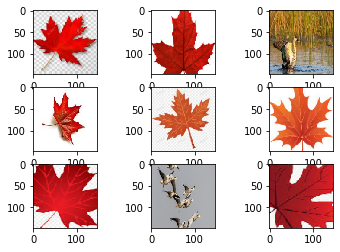

```
Dataset Verification after adding Data Augmentation
Batch shape: X= (10, 148, 148, 3)
Range of rescale: min= 0.0 , max= 1.0
Model: "sequential_3"
_________________________________________________________________
Layer (type)                 Output Shape              Param #
=================================================================
conv2d_12 (Conv2D)           (None, 146, 146, 64)      1792
_________________________________________________________________
activation_18 (Activation)   (None, 146, 146, 64)      0
_________________________________________________________________
max_pooling2d_12 (MaxPooling (None, 73, 73, 64)        0
_________________________________________________________________
conv2d_13 (Conv2D)           (None, 71, 71, 64)        36928
_________________________________________________________________
activation_19 (Activation)   (None, 71, 71, 64)        0
_________________________________________________________________
max_pooling2d_13 (MaxPooling (None, 35, 35, 64)        0
_________________________________________________________________
conv2d_14 (Conv2D)           (None, 33, 33, 32)        18464
_________________________________________________________________
activation_20 (Activation)   (None, 33, 33, 32)        0
_________________________________________________________________
max_pooling2d_14 (MaxPooling (None, 16, 16, 32)        0
_________________________________________________________________
conv2d_15 (Conv2D)           (None, 14, 14, 32)        9248
_________________________________________________________________
activation_21 (Activation)   (None, 14, 14, 32)        0
_________________________________________________________________
max_pooling2d_15 (MaxPooling (None, 7, 7, 32)          0
_________________________________________________________________
flatten_3 (Flatten)          (None, 1568)              0
_________________________________________________________________
dense_6 (Dense)              (None, 16)                25104
_________________________________________________________________
activation_22 (Activation)   (None, 16)                0
_________________________________________________________________
dense_7 (Dense)              (None, 1)                 17
_________________________________________________________________
activation_23 (Activation)   (None, 1)                 0
```

[output cut: 27 more lines]

```
10/10 - 4s - loss: 0.1838 - accuracy: 0.9400 - val_loss: 0.2190 - val_accuracy: 0.9000
10/10 - 4s - loss: 0.1005 - accuracy: 0.9700 - val_loss: 0.2890 - val_accuracy: 0.8667
10/10 - 4s - loss: 0.0914 - accuracy: 0.9700 - val_loss: 0.8210 - val_accuracy: 0.8333
10/10 - 4s - loss: 0.1245 - accuracy: 0.9700 - val_loss: 0.5403 - val_accuracy: 0.8667
10/10 - 3s - loss: 0.1797 - accuracy: 0.9600 - val_loss: 0.4358 - val_accuracy: 0.8333
10/10 - 3s - loss: 0.1326 - accuracy: 0.9700 - val_loss: 0.5070 - val_accuracy: 0.8333
10/10 - 3s - loss: 0.1519 - accuracy: 0.9600 - val_loss: 0.4515 - val_accuracy: 0.8667
10/10 - 3s - loss: 0.2197 - accuracy: 0.9400 - val_loss: 0.3888 - val_accuracy: 0.9000
10/10 - 3s - loss: 0.1091 - accuracy: 0.9600 - val_loss: 0.2776 - val_accuracy: 0.9333
10/10 - 3s - loss: 0.1031 - accuracy: 0.9800 - val_loss: 0.3380 - val_accuracy: 0.9000
10/10 - 3s - loss: 0.1534 - accuracy: 0.9600 - val_loss: 0.4724 - val_accuracy: 0.8333
10/10 - 4s - loss: 0.1083 - accuracy: 0.9600 - val_loss: 0.2264 - val_accuracy: 0.9333
10/10 - 4s - loss: 0.1090 - accuracy: 0.9700 - val_loss: 0.3366 - val_accuracy: 0.9333
Total Training Time (second): 68.80479001998901
Visualize the progress our network makes on the loss and accuracy as the number of epochs increases.
```

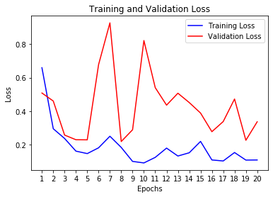

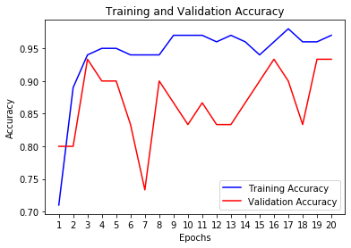

```
Prediction using test set.
WARNING:tensorflow:sample_weight modes were coerced from
  ...
    to
  ['...']
3/3 - 0s - loss: 1.0138 - accuracy: 0.6667
0.6666667
```

```python
print('Apply Zoom of augmentation method')

datagen_aug3 = ImageDataGenerator(rescale = 1/255., zoom_range=[0.5,1.0])


print('-----Load and iterate TRAIN, TEST, VALIDATION using "flow_from_directory"')
train_gen = datagen_aug3.flow_from_directory(train_dir, target_size=(v_width, v_height), class_mode='binary', batch_size=v_batch_size)

print('==================================================================================================================')
print(' Dataset Verification')
train_data, train_labels = train_gen.next()
print('Batch shape: X=', (train_data.shape))
print('Range of rescale: min=', train_data.min(),', max=', train_data.max())

val_data, val_labels = val_gen.next()
test_data, test_labels = test_gen.next()

print('*PLOT 9 FIRST IMAGES')
for i in range(9):
    plt.subplot(330 + 1 + i)
    plt.imshow(train_data[i]) # plot raw pixel data
plt.show()

print('Dataset Verification after adding Data Augmentation ')
train_data, train_labels = train_gen.next()
print('Batch shape: X=', (train_data.shape))
print('Range of rescale: min=', train_data.min(),', max=', train_data.max())


p_loss = 'binary_crossentropy'
p_metrics = 'accuracy'
p_epochs=20
p_batch_size=3
p_optimizer= 'rmsprop' #rmsprop
model = fn_BuildModel(p_optimizer,p_loss,p_metrics)
model.summary()
fn_Train('Sequential Model',model,train_gen, p_epochs, p_batch_size, val_gen, test_gen)
```

```
Apply brightness of augmentation method
-----Load and iterate TRAIN, TEST, VALIDATION using "flow_from_directory"
Found 100 images belonging to 2 classes.
==================================================================================================================
 Dataset Verification
Batch shape: X= (10, 148, 148, 3)
Range of rescale: min= 0.0 , max= 0.94117653
*PLOT 9 FIRST IMAGES
```

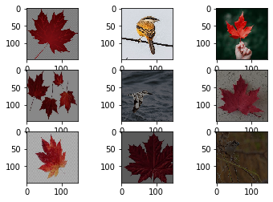

```
Dataset Verification after adding Data Augmentation
Batch shape: X= (10, 148, 148, 3)
Range of rescale: min= 0.0 , max= 0.9960785
Model: "sequential_4"
_________________________________________________________________
Layer (type)                 Output Shape              Param #
=================================================================
conv2d_16 (Conv2D)           (None, 146, 146, 64)      1792
_________________________________________________________________
activation_24 (Activation)   (None, 146, 146, 64)      0
_________________________________________________________________
max_pooling2d_16 (MaxPooling (None, 73, 73, 64)        0
_________________________________________________________________
conv2d_17 (Conv2D)           (None, 71, 71, 64)        36928
_________________________________________________________________
activation_25 (Activation)   (None, 71, 71, 64)        0
_________________________________________________________________
max_pooling2d_17 (MaxPooling (None, 35, 35, 64)        0
_________________________________________________________________
conv2d_18 (Conv2D)           (None, 33, 33, 32)        18464
_________________________________________________________________
activation_26 (Activation)   (None, 33, 33, 32)        0
_________________________________________________________________
max_pooling2d_18 (MaxPooling (None, 16, 16, 32)        0
_________________________________________________________________
conv2d_19 (Conv2D)           (None, 14, 14, 32)        9248
_________________________________________________________________
activation_27 (Activation)   (None, 14, 14, 32)        0
_________________________________________________________________
max_pooling2d_19 (MaxPooling (None, 7, 7, 32)          0
_________________________________________________________________
flatten_4 (Flatten)          (None, 1568)              0
_________________________________________________________________
dense_8 (Dense)              (None, 16)                25104
_________________________________________________________________
activation_28 (Activation)   (None, 16)                0
_________________________________________________________________
dense_9 (Dense)              (None, 1)                 17
_________________________________________________________________
activation_29 (Activation)   (None, 1)                 0
```

[output cut: 27 more lines]

```
10/10 - 3s - loss: 0.1373 - accuracy: 0.9700 - val_loss: 0.1928 - val_accuracy: 0.9333
10/10 - 3s - loss: 0.1492 - accuracy: 0.9500 - val_loss: 0.3321 - val_accuracy: 0.8667
10/10 - 3s - loss: 0.1425 - accuracy: 0.9700 - val_loss: 0.1925 - val_accuracy: 0.9333
10/10 - 3s - loss: 0.1243 - accuracy: 0.9700 - val_loss: 0.1538 - val_accuracy: 0.9667
10/10 - 3s - loss: 0.1539 - accuracy: 0.9600 - val_loss: 0.0921 - val_accuracy: 0.9667
10/10 - 3s - loss: 0.0701 - accuracy: 0.9700 - val_loss: 0.3116 - val_accuracy: 0.9667
10/10 - 3s - loss: 0.1498 - accuracy: 0.9500 - val_loss: 0.1525 - val_accuracy: 0.9667
10/10 - 3s - loss: 0.0468 - accuracy: 0.9900 - val_loss: 3.5933 - val_accuracy: 0.5000
10/10 - 3s - loss: 0.3500 - accuracy: 0.8800 - val_loss: 0.2454 - val_accuracy: 0.9667
10/10 - 3s - loss: 0.0693 - accuracy: 0.9900 - val_loss: 0.1225 - val_accuracy: 0.9667
10/10 - 3s - loss: 0.0611 - accuracy: 0.9900 - val_loss: 0.0721 - val_accuracy: 0.9667
10/10 - 3s - loss: 0.0663 - accuracy: 0.9800 - val_loss: 0.4154 - val_accuracy: 0.8667
10/10 - 3s - loss: 0.0716 - accuracy: 0.9800 - val_loss: 0.0699 - val_accuracy: 0.9667
Total Training Time (second): 62.74163508415222
Visualize the progress our network makes on the loss and accuracy as the number of epochs increases.
```

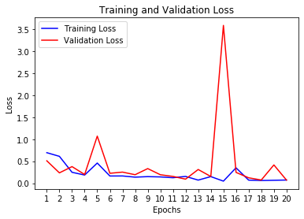

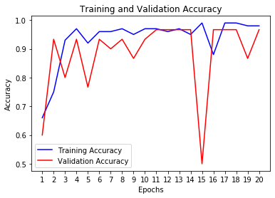

```
Prediction using test set.
WARNING:tensorflow:sample_weight modes were coerced from
  ...
    to
  ['...']
3/3 - 0s - loss: 0.4421 - accuracy: 0.8000
0.8
```

```python
print('Apply brightness of augmentation method')

datagen_aug4 = ImageDataGenerator(rescale = 1/255., brightness_range=[0.2,1.0])


print('-----Load and iterate TRAIN, TEST, VALIDATION using "flow_from_directory"')
train_gen = datagen_aug4.flow_from_directory(train_dir, target_size=(v_width, v_height), class_mode='binary', batch_size=v_batch_size)

print('==================================================================================================================')
print(' Dataset Verification')
train_data, train_labels = train_gen.next()
print('Batch shape: X=', (train_data.shape))
print('Range of rescale: min=', train_data.min(),', max=', train_data.max())

val_data, val_labels = val_gen.next()
test_data, test_labels = test_gen.next()

print('*PLOT 9 FIRST IMAGES')
for i in range(9):
    plt.subplot(330 + 1 + i)
    plt.imshow(train_data[i]) # plot raw pixel data
plt.show()

print('Dataset Verification after adding Data Augmentation ')
train_data, train_labels = train_gen.next()
print('Batch shape: X=', (train_data.shape))
print('Range of rescale: min=', train_data.min(),', max=', train_data.max())


p_loss = 'binary_crossentropy'
p_metrics = 'accuracy'
p_epochs=20
p_batch_size=3
p_optimizer= 'rmsprop' #rmsprop
model = fn_BuildModel(p_optimizer,p_loss,p_metrics)
model.summary()
fn_Train('Sequential Model',model,train_gen, p_epochs, p_batch_size, val_gen, test_gen)
```

```
Tuning Model
Create a data generator with the input parameter "rescale" to determine that the image pixel values are rescaled between 0 and 1.
-----Load and iterate TRAIN, TEST, VALIDATION using "flow_from_directory"
Found 100 images belonging to 2 classes.
Found 30 images belonging to 2 classes.
Found 30 images belonging to 2 classes.
==================================================================================================================
Dataset Verification
Batch shape: X= (10, 148, 148, 3)
Range of rescale: min= 0.0 , max= 1.0
*PLOT 9 FIRST IMAGES
```

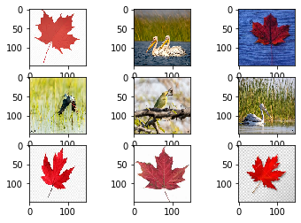

```
Model: "sequential_5"
_________________________________________________________________
Layer (type)                 Output Shape              Param #
=================================================================
conv2d_20 (Conv2D)           (None, 146, 146, 64)      1792
_________________________________________________________________
activation_30 (Activation)   (None, 146, 146, 64)      0
_________________________________________________________________
conv2d_21 (Conv2D)           (None, 144, 144, 64)      36928
_________________________________________________________________
activation_31 (Activation)   (None, 144, 144, 64)      0
_________________________________________________________________
max_pooling2d_20 (MaxPooling (None, 72, 72, 64)        0
_________________________________________________________________
conv2d_22 (Conv2D)           (None, 70, 70, 128)       73856
_________________________________________________________________
activation_32 (Activation)   (None, 70, 70, 128)       0
_________________________________________________________________
conv2d_23 (Conv2D)           (None, 68, 68, 128)       147584
_________________________________________________________________
activation_33 (Activation)   (None, 68, 68, 128)       0
_________________________________________________________________
max_pooling2d_21 (MaxPooling (None, 34, 34, 128)       0
_________________________________________________________________
conv2d_24 (Conv2D)           (None, 32, 32, 256)       295168
_________________________________________________________________
activation_34 (Activation)   (None, 32, 32, 256)       0
_________________________________________________________________
conv2d_25 (Conv2D)           (None, 30, 30, 256)       590080
_________________________________________________________________
activation_35 (Activation)   (None, 30, 30, 256)       0
_________________________________________________________________
max_pooling2d_22 (MaxPooling (None, 15, 15, 256)       0
_________________________________________________________________
conv2d_26 (Conv2D)           (None, 13, 13, 512)       1180160
_________________________________________________________________
activation_36 (Activation)   (None, 13, 13, 512)       0
_________________________________________________________________
conv2d_27 (Conv2D)           (None, 11, 11, 512)       2359808
_________________________________________________________________
```

[output cut: 48 more lines]

```
10/10 - 24s - loss: 0.7030 - accuracy: 0.5000 - val_loss: 0.6948 - val_accuracy: 0.5000
10/10 - 23s - loss: 0.7493 - accuracy: 0.5000 - val_loss: 0.6933 - val_accuracy: 0.5000
10/10 - 22s - loss: 0.6938 - accuracy: 0.5000 - val_loss: 0.6932 - val_accuracy: 0.5000
10/10 - 22s - loss: 0.6937 - accuracy: 0.5000 - val_loss: 0.6932 - val_accuracy: 0.5000
10/10 - 21s - loss: 0.6937 - accuracy: 0.5000 - val_loss: 0.6932 - val_accuracy: 0.5000
10/10 - 21s - loss: 0.6928 - accuracy: 0.5200 - val_loss: 1.8525 - val_accuracy: 0.5000
10/10 - 22s - loss: 0.7833 - accuracy: 0.5200 - val_loss: 0.6932 - val_accuracy: 0.5000
10/10 - 22s - loss: 0.6924 - accuracy: 0.5200 - val_loss: 0.6029 - val_accuracy: 0.5000
10/10 - 23s - loss: 0.9804 - accuracy: 0.6000 - val_loss: 0.6937 - val_accuracy: 0.5000
10/10 - 22s - loss: 0.7436 - accuracy: 0.5000 - val_loss: 0.6932 - val_accuracy: 0.5000
10/10 - 22s - loss: 0.9391 - accuracy: 0.5600 - val_loss: 0.6933 - val_accuracy: 0.5000
10/10 - 22s - loss: 0.7383 - accuracy: 0.5000 - val_loss: 0.6649 - val_accuracy: 0.5333
10/10 - 25s - loss: 1.9584 - accuracy: 0.7300 - val_loss: 0.7036 - val_accuracy: 0.5000
Total Training Time (second): 447.01105642318726
Visualize the progress our network makes on the loss and accuracy as the number of epochs increases.
```

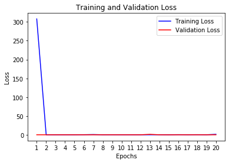

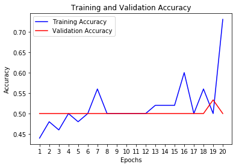

```
Prediction using test set.
WARNING:tensorflow:sample_weight modes were coerced from
  ...
    to
  ['...']
3/3 - 1s - loss: 0.7082 - accuracy: 0.5000
0.5
```

```python
print('Tuning Model')


def fn_Build_OptimizedModel(p_optimizer,p_loss,p_metrics):
    model = Sequential()
    model.add(Conv2D(64, (3, 3), input_shape=input_shape))
    model.add(Activation('relu'))
    model.add(Conv2D(64, (3, 3)))
    model.add(Activation('relu'))
    model.add(MaxPooling2D(pool_size=(2, 2), strides=(2,2)))
    Dropout(0.2)

    model.add(Conv2D(128, (3, 3)))
    model.add(Activation('relu'))
    model.add(Conv2D(128, (3, 3)))
    model.add(Activation('relu'))
    model.add(MaxPooling2D(pool_size=(2, 2)))
    Dropout(0.2)

    model.add(Conv2D(256, (3, 3)))
    model.add(Activation('relu'))
    model.add(Conv2D(256, (3, 3)))
    model.add(Activation('relu'))
    model.add(MaxPooling2D(pool_size=(2, 2)))
    Dropout(0.2)

    model.add(Conv2D(512, (3, 3)))
    model.add(Activation('relu'))
    model.add(Conv2D(512, (3, 3)))
    model.add(Activation('relu'))
    model.add(Conv2D(512, (3, 3)))
    model.add(Activation('relu'))
    model.add(MaxPooling2D(pool_size=(2, 2)))
    Dropout(0.2)

    model.add(Flatten())
    model.add(Dense(4096))
    model.add(Activation('relu'))
    model.add(Dense(4096))
    model.add(Activation('relu'))
    Dropout(0.2)

    model.add(Dense(1))
    model.add(Activation('sigmoid'))

    model.compile(optimizer=p_optimizer,
                loss=p_loss,
                metrics=[p_metrics])

    return model


print('Create a data generator with the input parameter "rescale" to determine that the image pixel values are rescaled between 0 and 1.')
datagen = ImageDataGenerator(rescale=1./255)

print('-----Load and iterate TRAIN, TEST, VALIDATION using "flow_from_directory"')
train_gen = datagen.flow_from_directory(train_dir, target_size=(v_width, v_height), class_mode='binary', batch_size=v_batch_size)
test_gen = datagen.flow_from_directory(test_dir, target_size=(v_width, v_height), class_mode='binary', batch_size=v_batch_size)
val_gen = datagen.flow_from_directory(val_dir, target_size=(v_width, v_height), class_mode='binary', batch_size=v_batch_size)

print('==================================================================================================================')
print('Dataset Verification')
train_data, train_labels = train_gen.next()
print('Batch shape: X=', (train_data.shape))
print('Range of rescale: min=', train_data.min(),', max=', train_data.max())

val_data, val_labels = val_gen.next()
test_data, test_labels = test_gen.next()

print('*PLOT 9 FIRST IMAGES')
for i in range(9):
    plt.subplot(330 + 1 + i)
    plt.imshow(train_data[i]) # plot raw pixel data
plt.show()


p_loss = 'binary_crossentropy'
p_metrics = 'accuracy'
p_epochs=20
p_batch_size=3
p_optimizer= 'rmsprop' #rmsprop
model = fn_Build_OptimizedModel(p_optimizer,p_loss,p_metrics)
model.summary()
fn_Train('Sequential Model',model,train_gen, p_epochs, p_batch_size, val_gen, test_gen)
```

### Regarding to Part 3 :

- Adding data augmentation methods is applied such as: rotation, horizontal and vertical flipping, zooming, brightness adjust. However, the models are not better, and overfitting issue has not resolved.
- The new model that is built with optimization purpose. However, the model is not better. It's even the worse model because the model cannot learn. The accuracty for train fluctuated from 0.4 to 0.7, but the accuracy of validation phases were not changed.

Due to having no more time, we decided to pause the practice here. However, adding augmentation data to increase the trainset is the step we will investigate more to improve the model.